# Exploratory analysis: Substantive procedures

This exploratory analysis focuses on the Substantive procedures dimension and includes various data summaries in table and graphical forms. The dimension is concpetualised as a construct related to the level of judicialization, basically a Political (high discretion) vs. Legal (judicial constriant).

# List of items

The Substantive Procedures scale has been constructed on the basis of some of these items:

| Item | Question |
| --- | --- |
| 24 | Is there a substantive admissibility check? |
| 25 | Who decides about the substantive admissibility? |
| 26 | Is there a legal remedy against the decision on substantive admissibility? |
| 27 | Who decides about the claim for remedy in the substantive admissibility procedure? |
| 28 | Who can initiate the substantive remedy procedure (state actor - initiator - anyone)? |
| 29 | Does the substantive admissibility procedure take place before the signature collection? |
| 31 | Do participants have a right to be heard in the substantive admissibility procedure? |
| 32 | Is there an evidentiary procedure in the substantive admissibility procedure? |
| 33 | Are the legal consequences of the substantive admissibility procedure binding? |
| 34 | Is invalidity the legal consequence of substantive inadmissibility? |

There are two important points:

- 1. Substantive procedures does not apply to the Law-Initiated instrument.
- 2. Item 29 (on checks before signature collection) does not apply to Executive, Legislature & Subnational. In this analysis this item is removed so we can make better comparisons.

# Data Summaries

For the summaries below the labels “Yes” (Legal) vs “No” (Political) are used interchangeably.

## Distribution of answers for item 24 on whether there is a substantive admisability check

#### Overall distribution item 24

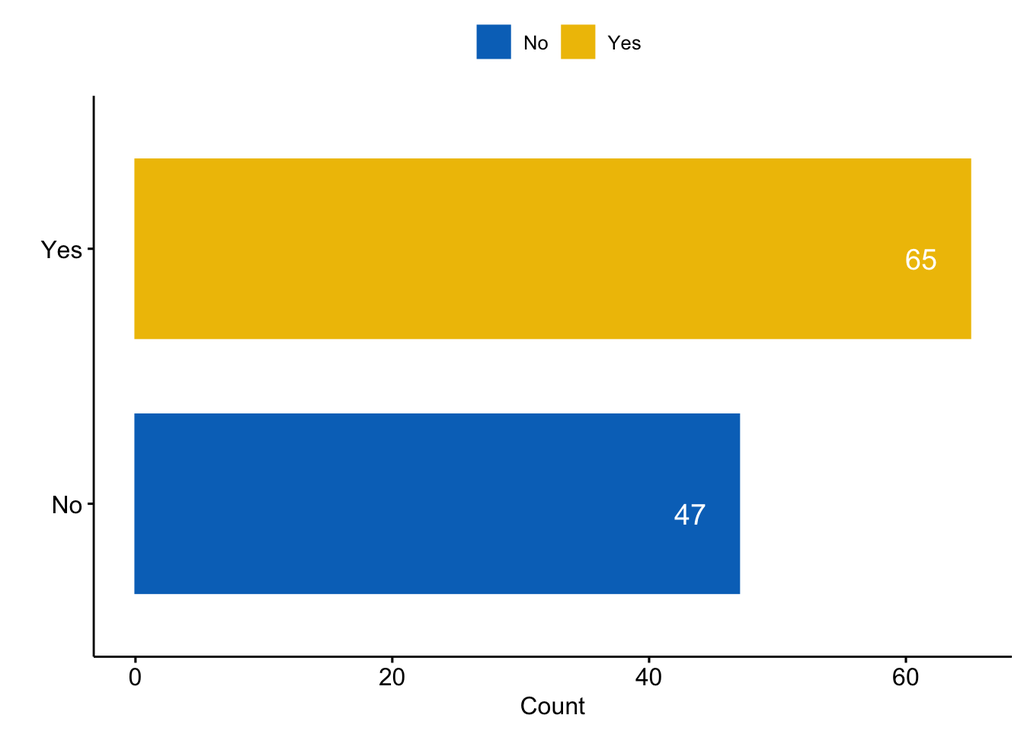

#### Distribution per instrument on whether there is a substantive admisability check for item 24

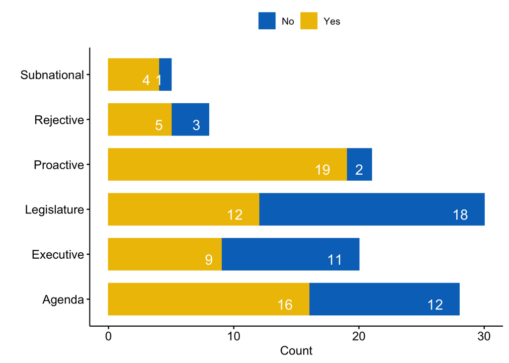

## All Substantive procedure limits items (Legal vs. Political)

#### Distribution of substantive procedure limits

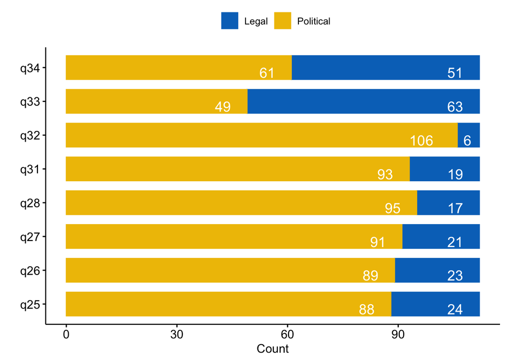

The main take home point here is that item 32 (is there an evidentiary procedure in the substantive admissibility procedure) is very rare, only in 6 instances out of 112 is there such a legal provision.

#### Distribution of items Legal vs. Political grouped by Instrument

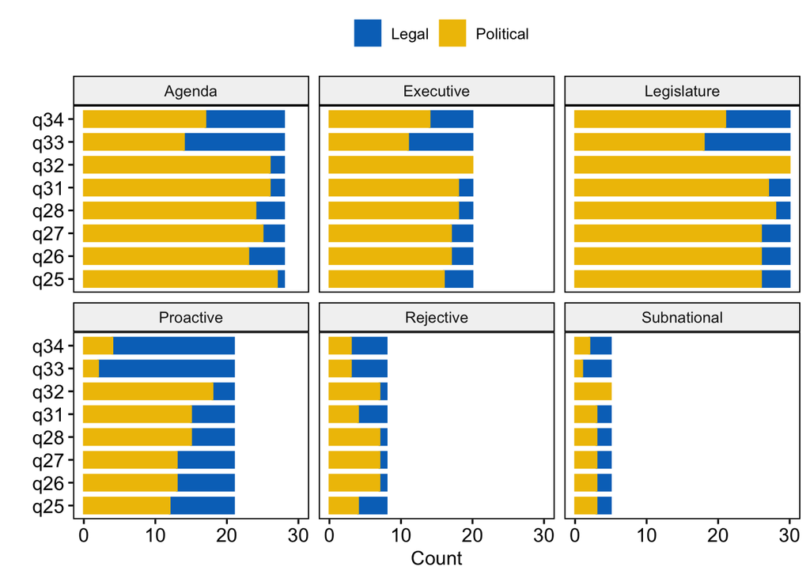

# Country check

Another aspect worth checking is the Country impact. The visualisation below allows us to check how Country affects substantive prohibitions. It is organised by the items on Y axis and the Countries on the X axis. The bubble represent the count (i.e., how many prohibitions a country has per item). This is related to the number of instruments a country has; thus a country with 4 instruments, will have a maximum number of 4 prohibitions.

#### Matrix of ‘Legal’ value counts for each item organised by country

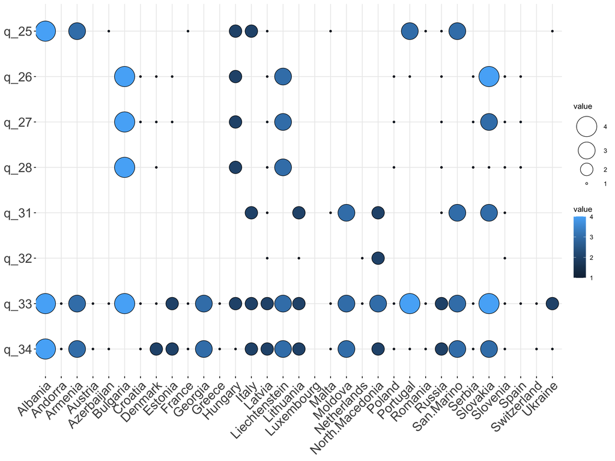

Visualising these country effects allows us to see whether a particular country is driving the count for a particular Item. We can see that item 32 (evidentiary procedures) and item 31 (right to be heard) are sparsely populated, whereas items 33 (binding procedures) and 34 (invalidity consequence) are not.

## Preliminary evaluation of scores

In the graph below we can place all cases on a putative Substantive Procedures dimension (Political vs Legal).

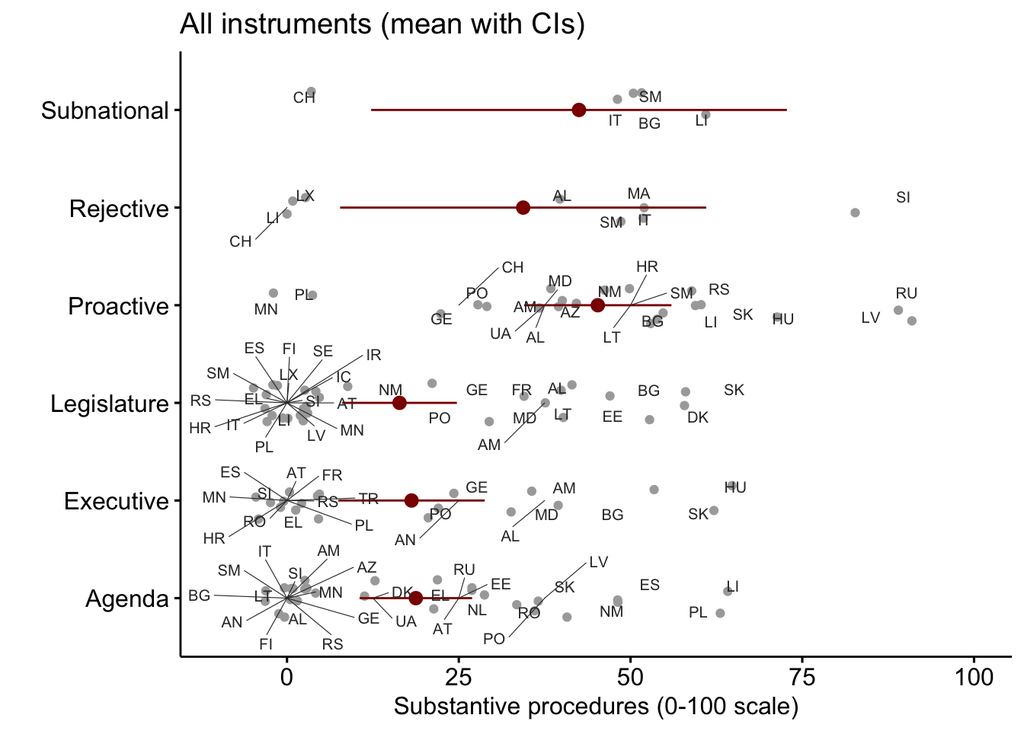

# Annex: Table of Country / Instrument distribution for item 24 on substantive admisability check

Note “Yes” (Legal) vs “No” (Political). An empty cell means the country does not provide for the particular instrument.

| Country | Agenda | Executive | Legislature | Proactive | Rejective | Subnational |
| --- | --- | --- | --- | --- | --- | --- |
| Albania | No | Yes | Yes | Yes | Yes |  |
| Andorra | Yes | Yes |  |  |  |  |
| Armenia | No | Yes | Yes | Yes |  |  |
| Austria | Yes | No | No |  |  |  |
| Azerbaijan | No |  |  | Yes |  |  |
| Bulgaria | No | Yes | Yes | Yes |  | Yes |
| Croatia |  | No | No | Yes |  |  |
| Denmark | Yes |  | Yes |  |  |  |
| Estonia | Yes |  | Yes |  |  |  |
| Finland | No |  | No |  |  |  |
| France |  | No | Yes |  |  |  |
| Georgia | No | Yes | Yes | Yes |  |  |
| Greece | Yes | No | No |  |  |  |
| Hungary |  | Yes |  | Yes |  |  |
| Iceland |  |  | No |  |  |  |
| Ireland |  |  | No |  |  |  |
| Italy | No |  | No |  | Yes | Yes |
| Latvia | Yes |  | No | Yes |  |  |
| Liechtenstein | Yes |  | No | Yes | No | Yes |
| Lithuania | No |  | Yes | Yes |  |  |
| Luxembourg |  |  | Yes |  | No |  |
| Malta |  |  |  |  | Yes |  |
| Moldova |  | Yes | Yes | Yes |  |  |
| Montenegro | No | No | No | No |  |  |
| Netherlands | Yes |  |  |  |  |  |
| North Macedonia | Yes |  | No | Yes |  |  |
| Poland | Yes | No | No | No |  |  |
| Portugal | Yes | Yes | Yes | Yes |  |  |
| Romania | Yes | No |  |  |  |  |
| Russia | Yes |  |  | Yes |  |  |
| San Marino | No |  | No | Yes | Yes | Yes |
| Serbia | No | No | No | Yes |  |  |
| Slovakia | Yes | Yes | Yes | Yes |  |  |
| Slovenia | No | No | No |  | Yes |  |
| Spain | Yes | No | No |  |  |  |
| Sweden |  |  | No |  |  |  |
| Switzerland |  |  |  | Yes | No | No |
| Turkey |  | No |  |  |  |  |
| UK |  |  | No |  |  |  |
| Ukraine | Yes |  |  | Yes |  |  |